# Data Analytics and Visualization with Python

- **NumPy**
  - Numerical Python, mảng N-chiều
- **Pandas**
  - Phân tích dữ liệu (Data Analytics)
- **Matplotlib**
  - Trực quan hóa dữ liệu cơ bản (Basic Data Visualization)
- **Seaborn**
  - Trực quan hóa nâng cao (Advanced Visualization)

## Numpy

cung cấp một đối tượng mảng đa chiều để lưu trữ dữ liệu đồng nhất hoặc không đồng nhất; nó cũng cung cấp các hàm/phương thức tối ưu để thao tác trên đối tượng mảng này.

```python
v = list(range(1, 6))
v
2 * v
import numpy as np
v = np.arange(1, 6)
v
2 * v
```

```
array([ 2,  4,  6,  8, 10])
```

### NumPy Create Array

```python
import numpy as np

a = np.zeros((2,2))      # Create an array of all zeros
print(a)                 # Prints "[[0. 0.]\n [0. 0.]]"

b = np.ones((2,2))       # Create an array of all ones
print(b)                 # Prints "[[1. 1.]\n [1. 1.]]"

c = np.full((2,2), 7)    # Create a constant array
print(c)                 # Prints "[[7. 7.]\n [7. 7.]]"

d = np.eye(2)            # Create a 2x2 identity matrix
print(d)                 # Prints "[[1. 0.]\n [0. 1.]]"

e = np.random.random((2,2)) # Create an array filled with random values
print(e)                 # Might print "[[0.91940167 0.08143941]\n [0.68744134 0.87236687]]"
```

```
[[0. 0.]
 [0. 0.]]
[[1. 1.]
 [1. 1.]]
[[7 7]
 [7 7]]
[[1. 0.]
 [0. 1.]]
[[0.14298153 0.68753529]
 [0.83421591 0.92690968]]
```

```python
import numpy as np
a = np.arange(15).reshape(3, 5)
a
```

```
array([[ 0,  1,  2,  3,  4],
       [ 5,  6,  7,  8,  9],
       [10, 11, 12, 13, 14]])
```

```python
print(a.shape)
```

```
(3, 5)
```

```python
print(a.ndim)
```

```
2
```

```python
a.dtype.name
```

```
'int32'
```

### One-dimensional Array

```python
import numpy as np
a = np.array([1,2,3,4,5])
a
```

```
array([1, 2, 3, 4, 5])
```

### Two-dimensional Array (2-D Array)

```python
a = np.array([[1,2,3,4,5],[6,7,8,9,10],[11,12,13,14,15],[16,17,18,19,20]])
a
```

```
array([[ 1,  2,  3,  4,  5],
       [ 6,  7,  8,  9, 10],
       [11, 12, 13, 14, 15],
       [16, 17, 18, 19, 20]])
```

```python
import numpy as np
a = np.array([[0, 1, 2, 3],
[10, 11, 12, 13],
[20, 21, 22, 23]])
a
```

```
array([[ 0,  1,  2,  3],
       [10, 11, 12, 13],
       [20, 21, 22, 23]])
```

```python
a = np.array([[0, 1, 2, 3], [10, 11, 12, 13], [20, 21, 22, 23]])
a
print(a.ndim)          # Number of dimensions
print(a.shape)         # Size of each dimension
```

```
2
(3, 4)
```

### NumPyBasics: Arrays and Vectorized Computation

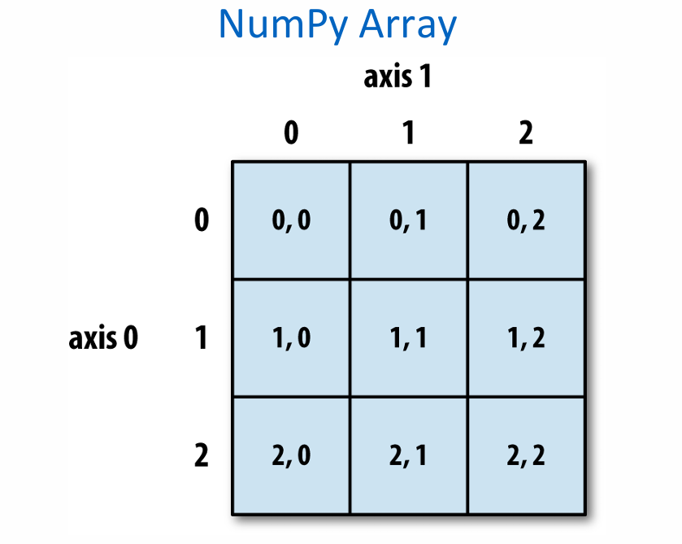

**1. `arr[:2, 1:] → (2, 2)`**

- `:2` → chọn **các hàng từ 0 đến 1** (2 hàng đầu).
- `1:` → chọn **các cột từ 1 đến hết** (2 cột cuối).  
  👉 Kết quả: mảng con kích thước **(2, 2)**.

**2. Index theo hàng**

- `arr[2] → (3,)`  
  Chỉ định hàng số `2` → NumPy trả về **nguyên hàng thứ 2** dạng 1D array (3 phần tử).
- `arr[2, :] → (3,)`  
  Tương tự, lấy hàng số `2` và tất cả các cột → vẫn là **1D array**.
- `arr[2:, :] → (1, 3)`  
  Ở đây dùng slicing `2:` thay vì chỉ số đơn → NumPy **giữ nguyên dạng 2D**.  
  Chọn từ hàng `2` đến hết → có **1 hàng, 3 cột**.  
  👉 Kích thước **(1, 3)**.

**3. `arr[:, :2] → (3, 2)`**

- `:` → chọn **tất cả các hàng**.
- `:2` → chọn **2 cột đầu**.  
  👉 Kết quả: ma trận con **3×2**.

**4. Khác biệt giữa chỉ số và slicing**

- `arr[1, :2] → (2,)`  
  `1` → chọn riêng hàng số 1.  
  `:2` → chọn 2 cột đầu.  
  👉 Kết quả là **1D array** dài 2.  
  Kích thước **(2,)**.
- `arr[1:2, :2] → (1, 2)`  
  `1:2` là **slicing** (không phải chỉ số đơn).  
  👉 Giữ nguyên dạng **2D**, kết quả là ma trận có 1 hàng, 2 cột.  
  Kích thước **(1, 2)**.

**✅ Điểm quan trọng**

- **Chỉ số đơn** (`arr[2]`, `arr[1, :2]`) → NumPy sẽ **giảm bậc** (ra 1D).
- **Slicing** (`arr[2:, :]`, `arr[1:2, :2]`) → NumPy **giữ nguyên bậc 2D**.

**Tensor**

- **3**
  - Đây là **rank 0 tensor** (scalar).
  - Kiểu: **scalar** với shape `[]`.
- **[1., 2., 3.]**
  - Đây là **rank 1 tensor** (vector).
  - Kiểu: **vector** với shape `[3]`.
- **[[1., 2., 3.], [4., 5., 6.]]**
  - Đây là **rank 2 tensor** (matrix).
  - Kiểu: **matrix** với shape `[2, 3]`.
- **[[[1., 2., 3.]], [[7., 8., 9.]]]**
  - Đây là **rank 3 tensor**.
  - Shape: `[2, 1, 3]`.

**✅ Tóm lại:**

- Rank 0 → **scalar** (số đơn lẻ).
- Rank 1 → **vector** (mảng 1 chiều).
- Rank 2 → **matrix** (ma trận 2 chiều).
- Rank ≥ 3 → **tensor bậc cao** (đa chiều).

## Pandas

- **Tabular data**: dữ liệu dạng **bảng** với các cột có kiểu dữ liệu khác nhau (**heterogeneously-typed columns**), giống như bảng trong **SQL** hoặc bảng tính trong **Excel**.
- **Time series data**: dữ liệu chuỗi thời gian có thể **có thứ tự hoặc không có thứ tự** (không nhất thiết phải theo tần suất cố định).
- **Arbitrary matrix data**: dữ liệu ma trận tùy ý — có thể đồng nhất kiểu (**homogeneously typed**) hoặc hỗn hợp kiểu (**heterogeneous**) — đi kèm với **row and column labels** (nhãn cho hàng và cột).
- **Observational / statistical data sets**: bất kỳ dạng tập dữ liệu quan sát hoặc thống kê nào khác.  
  👉 Thực tế thì dữ liệu **không nhất thiết phải có nhãn** mới có thể được đưa vào một cấu trúc dữ liệu của **pandas**.

### Series DataFrame

**Primary data structures of pandas**

- **Series (1-dimensional)**  
  Cấu trúc dữ liệu 1 chiều trong pandas.
- **DataFrame (2-dimensional)**  
  Cấu trúc dữ liệu 2 chiều trong pandas.
- Các cấu trúc này có thể xử lý **hầu hết các trường hợp sử dụng điển hình** trong:
  - **finance** (tài chính)
  - **statistics** (thống kê)
  - **social science** (khoa học xã hội)
  - và nhiều lĩnh vực **engineering** (kỹ thuật).

### Comparison with SAS

**pandas vs SAS**

| pandas | SAS |
| --- | --- |
| DataFrame | data set |
| column | variable |
| row | observation |
| groupby | BY-group |
| NaN | . |

```python
import pandas as pd
df = pd.DataFrame({"a": [4, 5, 6],
                    "b": [7, 8, 9],
                    "c": [10, 11, 12]},
                    index = [1, 2, 3])
```

```python
type(df)
```

```
pandas.core.frame.DataFrame
```

```python
import numpy as np
import pandas as pd
import matplotlib.pyplot as plt
print('pandas imported')
```

```
pandas imported
```

```python
s = pd.Series([1,3,5,np.nan,6,8])
s
```

```
0    1.0
1    3.0
2    5.0
3    NaN
4    6.0
5    8.0
dtype: float64
```

```python
dates = pd.date_range('20181001',
periods=6)
dates
```

```
DatetimeIndex(['2018-10-01', '2018-10-02', '2018-10-03', '2018-10-04',
               '2018-10-05', '2018-10-06'],
              dtype='datetime64[ns]', freq='D')
```

```python
df = pd.DataFrame(np.random.randn(6,4),
index=dates, columns=list('ABCD'))
df
```

|  | A | B | C | D |
| --- | --- | --- | --- | --- |
| 2018-10-01 | 2.803003 | 0.329624 | 0.249215 | 1.284956 |
| 2018-10-02 | 0.343032 | -0.853657 | 1.619295 | 0.977333 |
| 2018-10-03 | 1.333680 | -0.663489 | 1.237492 | -1.261627 |
| 2018-10-04 | 0.015077 | -1.008698 | 0.600549 | -1.194234 |
| 2018-10-05 | -0.348477 | -0.418129 | 0.722561 | 1.444975 |
| 2018-10-06 | 1.845602 | 2.375052 | -1.388265 | -1.884136 |

```python
df = pd.DataFrame(np.random.randn(3,5),
index=['student1','student2','student3']
 , columns=list('ABCDE'))
df
```

|  | A | B | C | D | E |
| --- | --- | --- | --- | --- | --- |
| student1 | -0.874671 | -0.151318 | -0.689984 | 2.649379 | 0.509841 |
| student2 | 1.105019 | -0.798602 | -0.142869 | -0.617553 | 0.782789 |
| student3 | 0.410421 | -0.667500 | 0.406705 | -1.043691 | 0.794824 |

```python
df2 = pd.DataFrame({ 'A' : 1.,
 'B' : pd.Timestamp('20181001'),
 'C' : pd.Series(2.5,index=list(range(4)),dtype='float32'),
 'D' : np.array([3] * 4,dtype='int32'),
 'E' : pd.Categorical(["test","train","test","train"]),
 'F' : 'foo' })
df2
```

|  | A | B | C | D | E | F |
| --- | --- | --- | --- | --- | --- | --- |
| 0 | 1.0 | 2018-10-01 | 2.5 | 3 | test | foo |
| 1 | 1.0 | 2018-10-01 | 2.5 | 3 | train | foo |
| 2 | 1.0 | 2018-10-01 | 2.5 | 3 | test | foo |
| 3 | 1.0 | 2018-10-01 | 2.5 | 3 | train | foo |

```python
df2.dtypes
```

```
A          float64
B    datetime64[s]
C          float32
D            int32
E         category
F           object
dtype: object
```

### Python Finance Application with Pandas

```python
import pandas as pd
# Create a DataFrameto store transactions
columns = ['Date', 'Description', 'Amount']
ledger = pd.DataFrame(columns=columns)
# Function to add a transaction
def add_transaction(date, description, amount):
    global ledger
    new_transaction= pd.DataFrame([[date, description, amount]], columns=columns)
    ledger = pd.concat([ledger, new_transaction], ignore_index=True)
# Function to view the ledger
def view_ledger():
    print(ledger)
# Function to get the current balance
def get_balance():
    return ledger['Amount'].sum()
# Adding sample transactions
add_transaction('2023-11-01', 'Income', 1000)
add_transaction('2023-11-02', 'Groceries', -200)
add_transaction('2023-11-03', 'Utilities', -100)
# Viewing the ledger
view_ledger()
# Checking the current balance
print("Current Balance:", get_balance())
```

```
         Date Description Amount
0  2023-11-01      Income   1000
1  2023-11-02   Groceries   -200
2  2023-11-03   Utilities   -100
Current Balance: 700
```

## Python matplotlib

### Iris Data Visualization

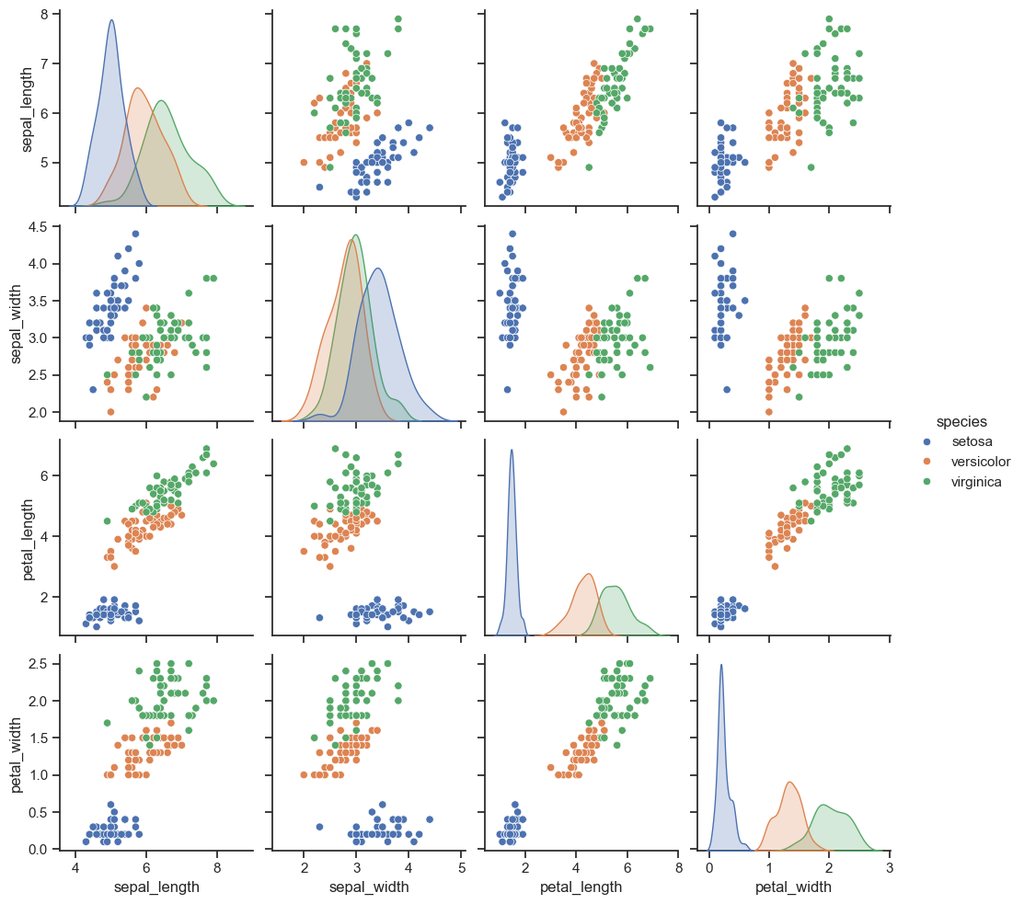

```python
import seaborn as sns
sns.set(style="ticks", color_codes=True)
iris = sns.load_dataset("iris")
g = sns.pairplot(iris, hue="species")
```

```python
import numpy as np
import pandas as pd
%matplotlib inline
import matplotlib.pyplot as plt
import seaborn as sns
from pandas.plotting import scatter_matrix
print("All libraries imported.")
```

[output not shown]

```python
url = "https://archive.ics.uci.edu/ml/machine-learning-databases/iris/iris.data"
names = ['sepal-length', 'sepal-width', 'petal-length', 'petal-width', 'class']
df = pd.read_csv(url, names=names)
print(df.head(10))
```

```
   sepal-length  sepal-width  petal-length  petal-width        class
0           5.1          3.5           1.4          0.2  Iris-setosa
1           4.9          3.0           1.4          0.2  Iris-setosa
2           4.7          3.2           1.3          0.2  Iris-setosa
3           4.6          3.1           1.5          0.2  Iris-setosa
4           5.0          3.6           1.4          0.2  Iris-setosa
5           5.4          3.9           1.7          0.4  Iris-setosa
6           4.6          3.4           1.4          0.3  Iris-setosa
7           5.0          3.4           1.5          0.2  Iris-setosa
8           4.4          2.9           1.4          0.2  Iris-setosa
9           4.9          3.1           1.5          0.1  Iris-setosa
```

```python
df.tail(10)
```

|  | sepal-length | sepal-width | petal-length | petal-width | class |
| --- | --- | --- | --- | --- | --- |
| 140 | 6.7 | 3.1 | 5.6 | 2.4 | Iris-virginica |
| 141 | 6.9 | 3.1 | 5.1 | 2.3 | Iris-virginica |
| 142 | 5.8 | 2.7 | 5.1 | 1.9 | Iris-virginica |
| 143 | 6.8 | 3.2 | 5.9 | 2.3 | Iris-virginica |
| 144 | 6.7 | 3.3 | 5.7 | 2.5 | Iris-virginica |
| 145 | 6.7 | 3.0 | 5.2 | 2.3 | Iris-virginica |
| 146 | 6.3 | 2.5 | 5.0 | 1.9 | Iris-virginica |
| 147 | 6.5 | 3.0 | 5.2 | 2.0 | Iris-virginica |
| 148 | 6.2 | 3.4 | 5.4 | 2.3 | Iris-virginica |
| 149 | 5.9 | 3.0 | 5.1 | 1.8 | Iris-virginica |

```python
df.describe()
```

|  | sepal-length | sepal-width | petal-length | petal-width |
| --- | --- | --- | --- | --- |
| count | 150.000000 | 150.000000 | 150.000000 | 150.000000 |
| mean | 5.843333 | 3.054000 | 3.758667 | 1.198667 |
| std | 0.828066 | 0.433594 | 1.764420 | 0.763161 |
| min | 4.300000 | 2.000000 | 1.000000 | 0.100000 |
| 25% | 5.100000 | 2.800000 | 1.600000 | 0.300000 |
| 50% | 5.800000 | 3.000000 | 4.350000 | 1.300000 |
| 75% | 6.400000 | 3.300000 | 5.100000 | 1.800000 |
| max | 7.900000 | 4.400000 | 6.900000 | 2.500000 |

```python
print(df.info())
print(df.shape)
```

```
<class 'pandas.core.frame.DataFrame'>
RangeIndex: 150 entries, 0 to 149
Data columns (total 5 columns):
 #   Column        Non-Null Count  Dtype
---  ------        --------------  -----
 0   sepal-length  150 non-null    float64
 1   sepal-width   150 non-null    float64
 2   petal-length  150 non-null    float64
 3   petal-width   150 non-null    float64
 4   class         150 non-null    object
dtypes: float64(4), object(1)
memory usage: 6.0+ KB
None
(150, 5)
```

```python
df.groupby('class').size()
```

```
class
Iris-setosa        50
Iris-versicolor    50
Iris-virginica     50
dtype: int64
```

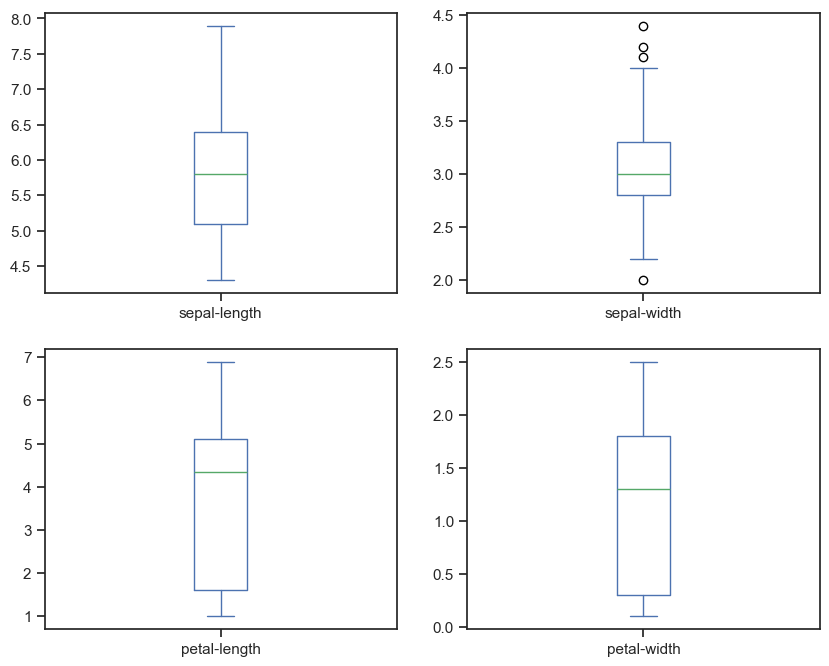

```python
plt.rcParams["figure.figsize"] = (10,8)
df.plot(kind='box', subplots=True, layout=(2,2), sharex=False, sharey=False)
plt.show()
```

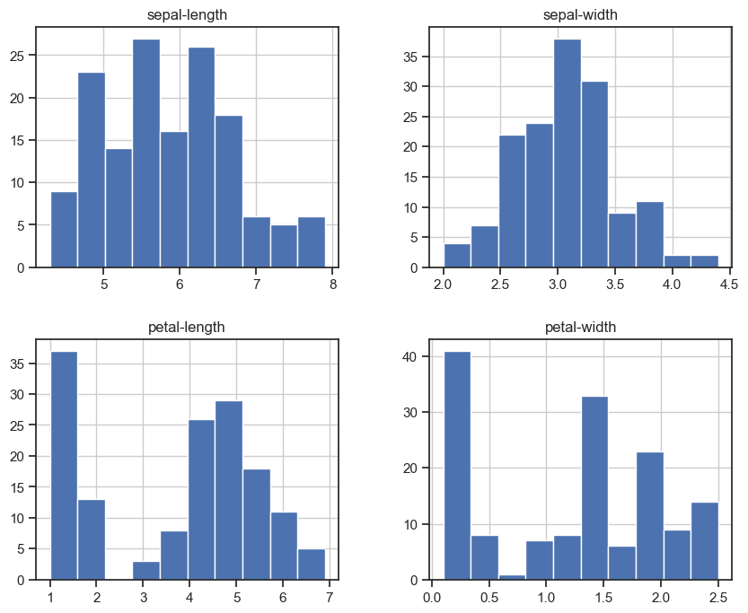

```python
df.hist()
plt.show()
```

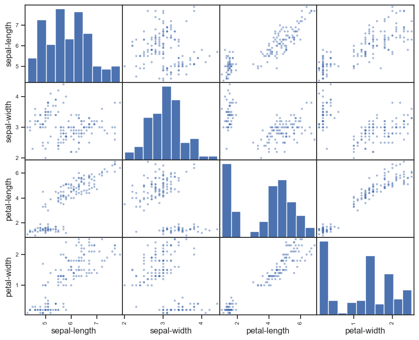

```python
from pandas.plotting import scatter_matrix
scatter_matrix(df)
plt.show()
```

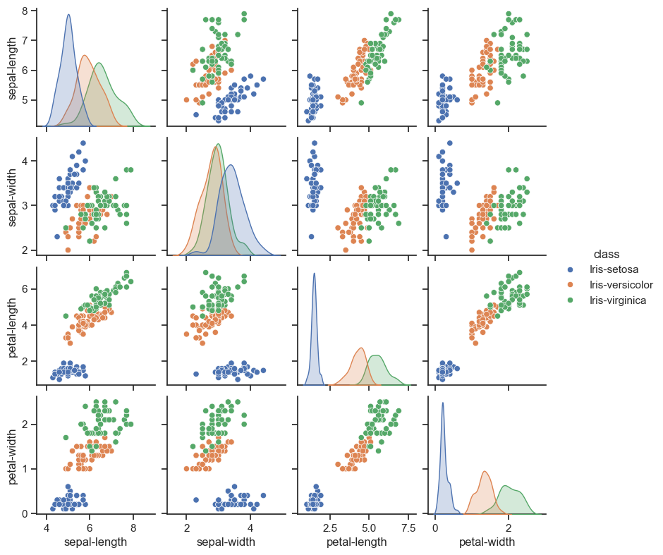

```python
sns.pairplot(df, hue="class", size=2)
```